# Summary Report of Pairings 1 2 5 12 And 16

Group 6

4/7/2021

## Pre-Analysis

```
## # A tibble: 2 x 4
##       A     n mean_outcome std_error
##   <int> <int>        <dbl>     <dbl>
## 1     0  1357         29.5     0.588
## 2     1   643        -45.7     2.59
```

```
##
##  Welch Two Sample t-test
##
## data:  Y by A
## t = 28.278, df = 708.98, p-value < 2.2e-16
## alternative hypothesis: true difference in means is not equal to 0
## 95 percent confidence interval:
##  69.95224 80.39043
## sample estimates:
## mean in group 0 mean in group 1
##        29.45850       -45.71284
```

```
## # A tibble: 2 x 4
##       A     n mean_outcome std_error
##   <int> <int>        <dbl>     <dbl>
## 1     0   394         16.6     0.531
## 2     1   106         27.2     1.49
```

```
##
##  Welch Two Sample t-test
##
## data:  Y by A
## t = -6.7071, df = 132.81, p-value = 5.201e-10
## alternative hypothesis: true difference in means is not equal to 0
## 95 percent confidence interval:
##  -13.728721  -7.475416
## sample estimates:
## mean in group 0 mean in group 1
##        16.56747        27.16953
```

# Causal Inference Methods

## Pairing 1

> Algorithm: `Propensity Matching` Distance Measure: `Mahalanobis` Propensity Score Estimation: `NA`

### Introduction of the algorithm

From https://cran.r-project.org/web/packages/MatchIt/vignettes/MatchIt.html#matching … “Although matching on the propensity score is often effective at eliminating differences between the treatment groups to achieve covariate balance, its performance in this regard must be assessed. If covariates remain imbalanced after matching, the matching is considered unsuccessful, and a different matching specification should be tried. MatchIt offers a few tools for the assessment of covariate balance after matching. These include graphical and statistical methods. More detail on the interpretation of the included plots and statistics can be found in vignette(”assessing-balance“). In addition to covariate balance, the quality of the match is determined by how many units remain after matching. Matching often involves discarding units that are not paired with other units, and some matching options, such as setting restrictions for common support or calipers, can further decrease the number of remaining units. If, after matching, the remaining sample size is small, the resulting effect estimate may be imprecise. In many cases, there will be a trade-off between balance and remaining sample size. How to optimally choose among them is an instance of the fundamental bias-variance trade-off problem that cannot be resolved without substantive knowledge of the phenomena under study. Prospective power analyses can be used to determine how small a sample can be before necessary precision is sacrificed.”

#### High Dim data

```
## ATE for high dimensional data is: -63.32722 .
```

```
## Processing time for high dimensional data is 2.187934 seconds.
```

```
## ATE error for high dimensional data is: 8.471422 .
```

#### Low Dim data

```
## ATE for low dimensional data is: 2.289205 .
```

```
## Processing time for low dimensional data is 0.7527962 seconds.
```

```
## ATE error for low dimensional data is: -0.199105 .
```

## Pairing 2

> Algorithm: `Propensity Matching` Distance Measure: `Propensity Score` Propensity Score Estimation: `Logistic Regression`

### Introduction of the algorithm

### optimal full matching

#### High Dim data

```
## ATE for high dimensional data is: -59.56389 .
```

```
## Processing time for high dimensional data is 8.575365 seconds.
```

```
## ATE error for high dimensional data is: 4.708088 .
```

#### Low Dim data

```
## ATE for low dimensional data is: 1.819887 .
```

```
## Processing time for low dimensional data is 0.505569 seconds.
```

```
## ATE error for low dimensional data is: 0.2702129 .
```

### subclassification

#### High Dim data

```
## ATE for high dimensional data is: -60.25466 .
```

```
## Processing time for high dimensional data is 0.8884609 seconds.
```

```
## ATE error for high dimensional data is: 5.398856 .
```

#### Low Dim data

```
## ATE for low dimensional data is: 2.409903 .
```

```
## Processing time for low dimensional data is 0.07777691 seconds.
```

```
## ATE error for low dimensional data is: -0.319803 .
```

## Pairing 5

> Algorithm: `Propensity Matching` Distance Measure: `Linear Propensity Score` Propensity Score Estimation: `Logistic Regression`

### Introduction of the algorithm

The distance of Propensity Score is defined as: $D_{ij}=|e_i-e_j|$ Obtained by applying the logit function on the Propensity Scores. Matching on the linear propensity score can be particularly effective in terms of reducing bias.

Linear propensity score matching is same with propensity score to entail forming matched sets of treated and untreated subjects who share a similar value of the propensity score. Once a matched sample has been formed, the treatment effect can be estimated by directly comparing outcomes between treated and untreated subjects in the matched sample. Once the effect of treatment has been estimated in the propensity score matched sample, the variance of the estimated treatment effect and its statistical significance can be estimated.

After the matched sets are obtained, Linear Propensity Score asks to calculate a “subclass effects” for each matched set/subclass, and then estimate overall ATE by an weighted average of the subclass effects where weights would be the number of individuals in each subclass.

### optimal full matching

#### High Dim data

```
## ATE for high dimensional data is: -60.14118 .
```

```
## Processing time for high dimensional data is 8.801819 seconds.
```

```
## ATE error for high dimensional data is: 5.28538 .
```

#### Low Dim data

```
## ATE for low dimensional data is: 1.725128 .
```

```
## Processing time for low dimensional data is 0.3844981 seconds.
```

```
## ATE error for low dimensional data is: 0.3649724 .
```

### subclassification

#### High Dim data

```
## ATE for high dimensional data is: -60.25466 .
```

```
## Processing time for high dimensional data is 0.864188 seconds.
```

```
## ATE error for high dimensional data is: 5.398856 .
```

#### Low Dim data

```
## ATE for low dimensional data is: 2.409903 .
```

```
## Processing time for low dimensional data is 0.04127908 seconds.
```

```
## ATE error for low dimensional data is: -0.319803 .
```

## Pairing 12

> Algorithm: `Doubly Robust Estimation` Distance Measure: `Propensity Score` Propensity Score Estimation: `Logistic Regression`

### Introduction of the algorithm

- The Doubly Robust Estimation has the smallest asymptotic variance. It remains consistent if the outcome models are wrong but the propensity model is right, or if the propensity model is wrong but the outcome models are right.
- Doubly Robust Estimator formula:
  $$\hat{\Delta_{DR}} = N^{-1}\sum_{i=1}^{N} \frac{T_iY_i-(T_i-\hat{e_i}) \hat{m_1}(X_i)}{\hat{e_i}} - N^{-1}\sum_{i=1}^{N} \frac{(1-T_i)Y_i-(T_i-\hat{e_i}) \hat{m_0}(X_i)}{1-\hat{e_i}}$$

where $\hat{e_i}$ is the estimated propensity score for individual $i$, $\hat{m_t}(X)$ is a consistent estimate for $E(Y|T=t,X)$ and is usually obtained by regressing the observed response Y on X in group t.

#### highDim data

```
## ATE for high dimensional data is: -56.42204 .
```

```
## Processing time for high dimensional data is 0.2304161 seconds.
```

```
## ATE error for high dimensional data is: 1.566241 .
```

#### lowDim data

```
## ATE for low dimensional data is: 2.067816 .
```

```
## Processing time for low dimensional data is 0.01403594 seconds.
```

```
## ATE error for low dimensional data is: 0.02228437 .
```

## Pairing 16

> Algorithm: `Stratification` Distance Measure: `Propensity Score` Propensity Score Estimation: `Logistic Regression`

### Introduction of the algorithm

#### Use Logistic regression to get the propensity score

```
## # A tibble: 2 x 2
##   treatment mean_prop_score
##       <int>           <dbl>
## 1         0           0.253
## 2         1           0.466
```

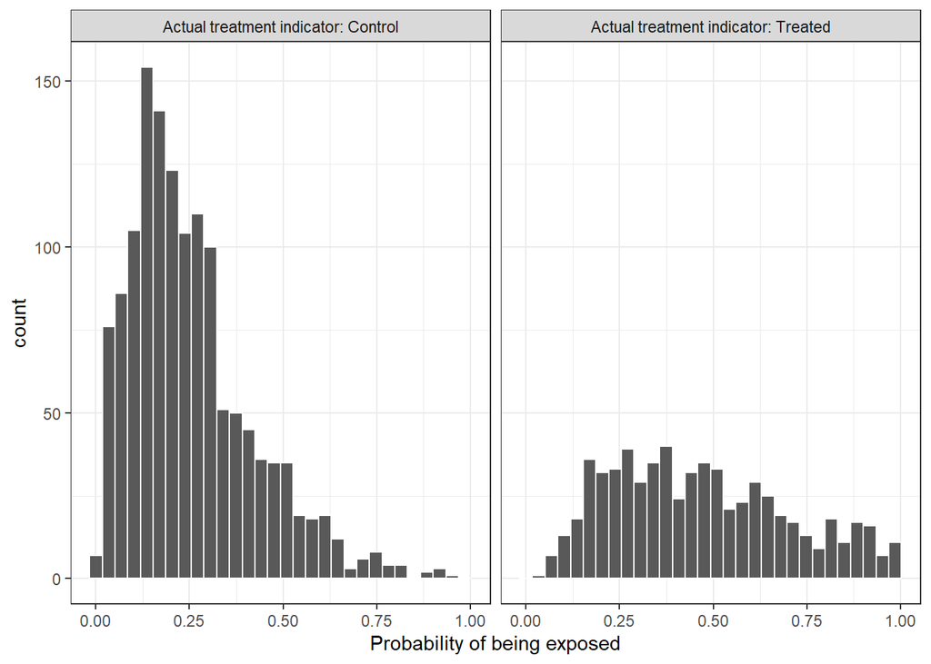

```
## # A tibble: 2 x 2
##   treatment mean_prop_score
##       <int>           <dbl>
## 1         0           0.181
## 2         1           0.329
```

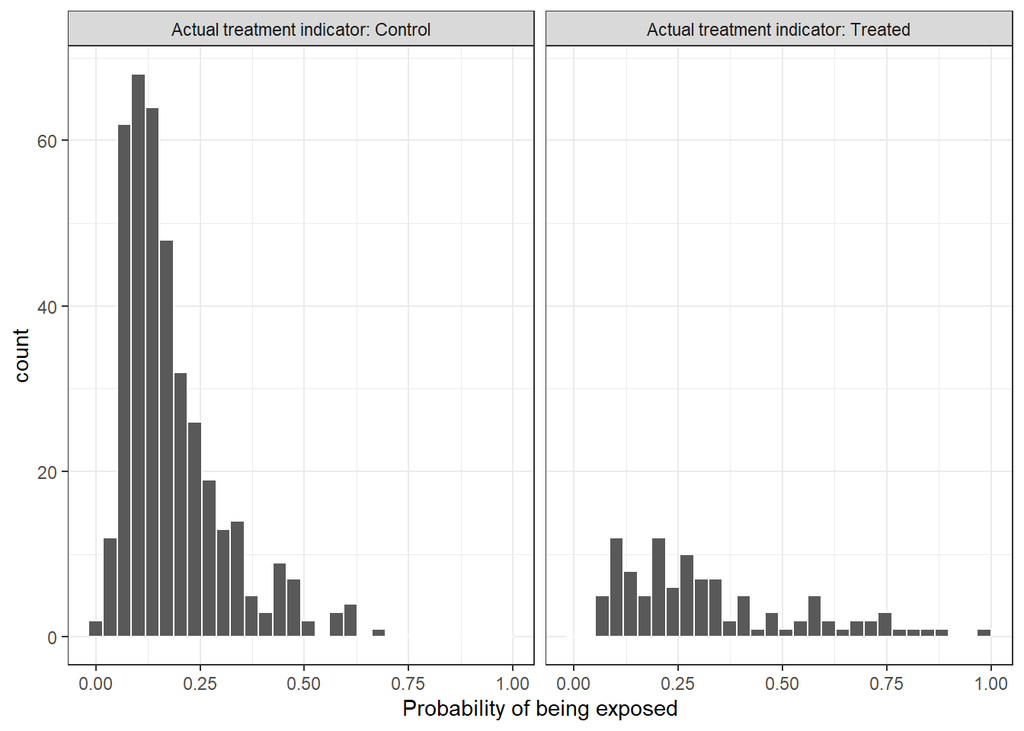

#### Perform stratification and find difference of means and weights.

#### Alternate Method that performs regression on each stratum by Y with A and Vs. Then averages the coefficients

### for A in each stratum to get the ATE

### Calculates the ATE and process time

#### High Dim data

```
## ATE for stratification is: -59.85656 .
```

```
## Processing time for stratification is NA seconds.
```

```
## ATE error for stratification is: 5.000763 .
```

```
##
## ATE for stratification alternative is: -53.97352 .
```

```
## Processing time for stratification is NA seconds.
```

```
## ATE error for stratification alternative is: -0.88228 .
```

#### Low Dim data

```
## ATE for stratification is: 2.012627 .
```

```
## Processing time for stratification is NA seconds.
```

```
## ATE error for stratification is: 0.07747324 .
```

```
##
## ATE for stratification alternative is: 2.243051 .
```

```
## Processing time for stratification is NA seconds.
```

```
## ATE error for stratification alternative is: -0.1529513 .
```